# Swinburne Open Science Task Force Survey (2019)

Jennifer L Beaudry

January 23, 2020

# Overview

We conducted a survey to examine people’s current use of open science practices, to examine their perceptions of these practices, and to examine their perceived barriers to using these practices.

This document presents an overview of their responses.

## Estimates of Reproducibility by Perceived Crisis

The black bar is the mean estimate of reproducibility according to the level of perceived crisis.

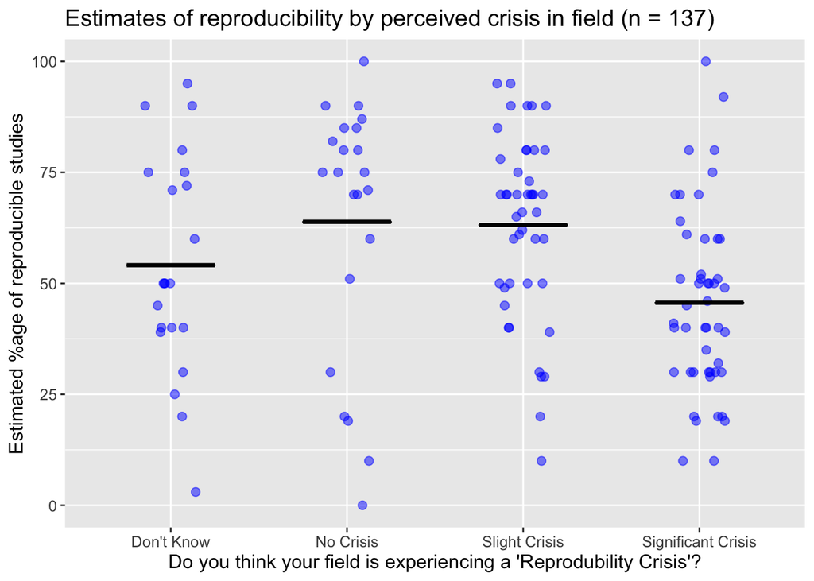

## Open Science Experience

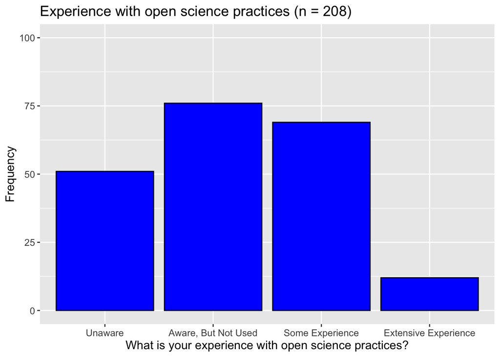

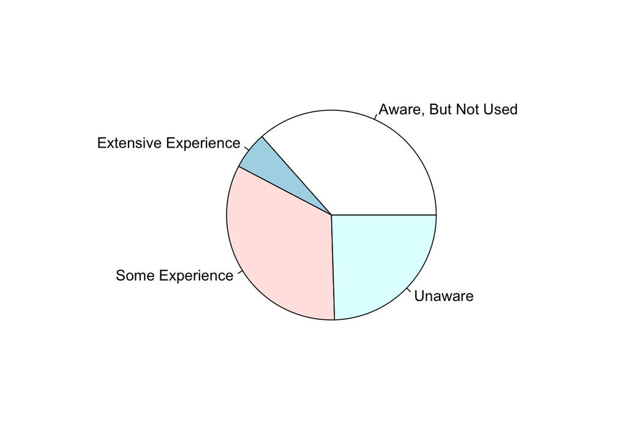

```r
# HOLY! This wasn't easy, but I got it. I can play with it more, now that I figured out how
  # to get it to actually work! Huh. Well, the code works alone, but doesn't knit. I will need
  # to play with it more...

# I find this formulation much easier than using pipes (%>%)
x <- filter(df,OverallExperience != "NA")

x2 <- x %>%
  dplyr::count(OverallExperience)
  pie(x2$n,labels=x2$OverallExperience)
```

### I need to figure out how to insert inline R code

# I had this working & now it’s not… and now it’s probably garbage…

# Inserted between backtick r and backtick I think

```r
#x3 <- df %>%
  #table(df$OverallExperience) %>%
  #  mutate ((freq = n / sum(n))*100) %>%
  #    round(digits = 2)
knitr::kable(x2, caption = 'In table form')
```

In table form

| OverallExperience | n |
| --- | --- |
| Aware, But Not Used | 76 |
| Extensive Experience | 12 |
| Some Experience | 69 |
| Unaware | 51 |

## Additional questions to include

### Experience with practices..

### Concerns with practices….

### Barriers…

```r
#As a quick first pass, we can use the 'skim()' function to get a simple overview of each variable:
#skim(df)
```

Now learning about group_by which appears to be a wonderful development!

```r
frames %>%
  group_by(test_item, sample_size, n_obs, condition) %>%
  summarise(response = mean(response)) %>% #can call "response" anything you want.
  ungroup() #get in this habit because otherwise you might retain the grouping elsewhere.
```

Now playing around with it to include more summary statistics, and to print out the different summary stats in a tiblle.

```r
frames %>%
  group_by(test_item) %>%
  summarise(
    mean_resp = mean(response),
    sd_resp = sd(response),
    count = n()
  ) %>%
  ungroup
```

Now play with filter to get summary stats from just a subset of the sample (their responses to only the ‘small’ objects).

```r
average_response <- frames %>%
  group_by(test_item, sample_size, n_obs, condition) %>%
  summarise(response = mean(response)) %>%
  ungroup ()

average_response %>%
  filter(sample_size == "small") #this is not changing the average response variable because it still has everything in it.
```

Now play with arrange to get summary stats from just a subset of the sample (their responses to only the ‘small’ objects), and arrange by condition.

```r
average_response <- frames %>%
  group_by (test_item, sample_size, n_obs, condition) %>%
  summarise (response = mean(response)) %>%
  ungroup ()

average_response %>%
  filter (sample_size == "small") %>%
  arrange (condition)
```

Now play with select to build on filter & arrange, but to only show some of the columns.

```r
average_response <- frames %>%
  group_by (test_item, sample_size, n_obs, condition) %>%
  summarise (response = mean(response)) %>%
  ungroup ()

average_response_small <- average_response %>%
  filter (sample_size == "small") %>%
  arrange (condition) %>%
  select (condition, test_item, response)

average_response_small
```

Now use mutate to create a new variable, which takes into account how many trials they completed.

```r
average_response_small <- average_response_small %>%
  mutate (generalisation = response/9) %>%
  select (-response) #now remove response because we don't need it any longer

average_response_small
```

## ————————————————–

## Tom’s stuff on data and code sharing starts here

## (starting point: copied Open Science section by JB)

## Open Code Experience

[figure not shown]